# TINDER PREDICTIVE INDICATORS

## L'income

A garder.

```python
# La donnée Income pertinentes ?
df1["income"].notnull().sum()
```

```
np.int64(4279)
```

```python
#Exploration de la colonne income
df1["income"]
```

```
0       69,487.00
1       69,487.00
2       69,487.00
3       69,487.00
4       69,487.00
          ...
8373          NaN
8374          NaN
8375          NaN
8376          NaN
8377          NaN
Name: income, Length: 8378, dtype: object
```

```python
#Conversion du type de Income en float64. Retrait de la virgule
df1["income"] = df1["income"].str.replace(',', '')
df1["income"]
```

```
0       69487.00
1       69487.00
2       69487.00
3       69487.00
4       69487.00
          ...
8373         NaN
8374         NaN
8375         NaN
8376         NaN
8377         NaN
Name: income, Length: 8378, dtype: object
```

```python
#Puis conversion
df1["income"].astype(float)
```

```
0       69487.0
1       69487.0
2       69487.0
3       69487.0
4       69487.0
         ...
8373        NaN
8374        NaN
8375        NaN
8376        NaN
8377        NaN
Name: income, Length: 8378, dtype: float64
```

```python
#La moitié des income pas dispo : c'est grave ? On peut se baser sur la population renseignée si les données manquantes ne sont pas liés à la variable cible (le match).
#Filtre sur les income renseigné : on crée un mask qui retourne "vrai" si la valeur n'est pas "NaN"
masknotnull = ~df1["income"].isna()
```

```python
#Filtre sur les income non renseigné : on crée un mask qui retourne "vrai" si la valeur est "NaN"
maskincomenull = df1["income"].isna()
```

```python
#Application du masque NotNull dans un nouveau dataframe
df1IncomeNotNull = df1.loc[masknotnull]
```

```python
#Application du masque Null dans un nouveau dataframe
df1IncomeNull = df1.loc[maskincomenull]
```

```python
#Vérification des opérations de conversion en float et de l'exclusion des NaN
df1IncomeNotNull["income"]
```

```
0       69487.00
1       69487.00
2       69487.00
3       69487.00
4       69487.00
          ...
8351    55138.00
8352    55138.00
8353    55138.00
8354    55138.00
8355    55138.00
Name: income, Length: 4279, dtype: object
```

```python
#Vérification des opérations de conversion en float et de l'exclusion des not NaN
df1IncomeNull["income"]
```

```
20      NaN
21      NaN
22      NaN
23      NaN
24      NaN
       ...
8373    NaN
8374    NaN
8375    NaN
8376    NaN
8377    NaN
Name: income, Length: 4099, dtype: object
```

```python
#Comparaison des 2 dataset Null et not null pour voir si la donnée Match est également réparti
# Les match "Oui" diffèrent de 15% selon que l'income soit rempli ou pas, un léger biais différentiel peut etre observé dans les
# prédiction
# 1. Comptage des "Yes" et "No" pour chaque DataFrame
count_not_null = df1IncomeNull['match2'].value_counts().reindex(['Yes', 'No'], fill_value=0)
count_null = df1IncomeNotNull['match2'].value_counts().reindex(['Yes', 'No'], fill_value=0)

# 2. Création du DataFrame final
result = pd.DataFrame({
    'countMatchYesIncomeNotNull': [count_not_null['Yes']],
    'countMatchNoIncomeNotNull': [count_not_null['No']],
    'countMatchYesIncomeNull': [count_null['Yes']],
    'countMatchNoIncomeNull': [count_null['No']]
})

# 3. Calcul du pourcentage d'écart pour "Yes" et "No"
result['percent_diff_Yes'] = (
    (result['countMatchYesIncomeNotNull'] - result['countMatchYesIncomeNull']) /
    result['countMatchYesIncomeNotNull'] * 100
)
result['percent_diff_No'] = (
    (result['countMatchNoIncomeNotNull'] - result['countMatchNoIncomeNull']) /
    result['countMatchNoIncomeNotNull'] * 100
)

# Affichage
result
```

[output not shown]

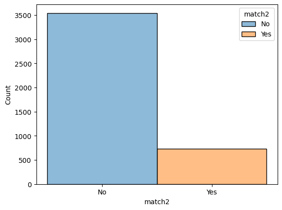

```python
# version visualisation en "box plot" de la girlle ci dessous pour les dataframe "avec" et"sans" income
sns.histplot(data=df1IncomeNotNull, x="match2", hue="match2")
```

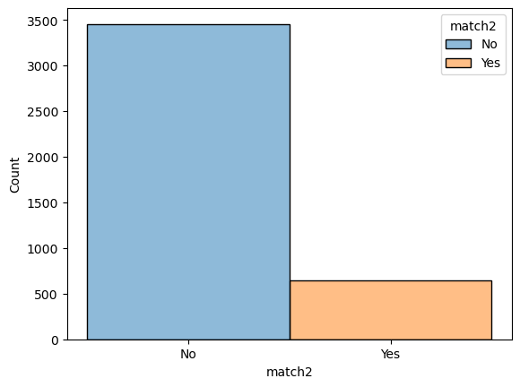

```python
sns.histplot(data=df1IncomeNull, x="match2", hue="match2")
```

```python
#Sur 4279 income renseigné, 261 sont uniques, le reste a la même valeur. Cela reste suffisant pour dresser des tendances
totalcountincome = df1IncomeNotNull["income"].count()
uniquecountincome = df1IncomeNotNull["income"].nunique()
uniquecountincomeduplicated = totalcountincome - uniquecountincome
print(totalcountincome)
print(uniquecountincome)
print(uniquecountincomeduplicated)
```

```
4279
261
4018
```

```python
#Pour analyser si les valeurs sont suffisamment distribué :
# Variabilité suffisante : écart type qui représente 38 % de la moyenne, distribution relativement étalée
df1IncomeNotNull["income"].astype("float64").describe()
```

```
count      4279.000000
mean      44887.606450
std       17206.920962
min        8607.000000
25%       31516.000000
50%       43185.000000
75%       54303.000000
max      109031.000000
Name: income, dtype: float64
```

[figure not shown]

```python
#Verification des outliners
sns.catplot(
    data=df1IncomeNotNull,
    x="income",
    kind="box",
    height=6,
    aspect=1.5
)
plt.title("Distribution du revenu (income)")
plt.show()
```

```python
#Création de catégories d'income pour une meilleure lisibilité
df1IncomeNotNull["income"] = df1IncomeNotNull["income"].astype("float64")
df1IncomeNotNull2 = df1IncomeNotNull
df1IncomeNotNull2["income"] = df1IncomeNotNull2["income"].apply(
    lambda x: "low" if x <= 31000
              else "mediumlow" if 31000 < x <= 43000
              else "mediumhigh" if 43000 < x <= 54000
              else "high"
)
```

```python
#On vérifie le résultat des conversions
df1IncomeNotNull2["income"]
```

```
0       high
1       high
2       high
3       high
4       high
        ...
8351    high
8352    high
8353    high
8354    high
8355    high
Name: income, Length: 4279, dtype: object
```

```python
#Filtre sur march = yes
maskNotNullMatched = (df1IncomeNotNull2["match2"] == "Yes")
```

```python
#Vérification du filtrage
df1IncomeNotNull2Matched = df1IncomeNotNull2.loc[maskNotNullMatched]
df1IncomeNotNull2Matched["match2"]
```

```
2       Yes
3       Yes
4       Yes
8       Yes
13      Yes
       ...
8201    Yes
8214    Yes
8215    Yes
8341    Yes
8346    Yes
Name: match2, Length: 736, dtype: object
```

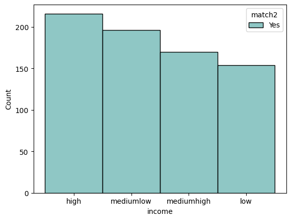

```python
sns.histplot(
    data=df1IncomeNotNull2Matched,
    x='income',
    hue='match2',
    palette='viridis'
)
```

## Conclusion : les revenus élevés sont plus susceptibles d'obtenir un match que les revenus faibles

## Selon les préférences d'activités

A garder

```python
#isoler le dataset avec juste les colonnes AY - B0
df1activities = df1.iloc[:, 50:67]
```

```python
df1activities.describe
```

[output not shown]

```python
"""Réarangement des préférences d'activités : je n'aime pas ou pas beaucoup = 0 (si score entre 1 et 5),
 j'aime un peu ou beaucoup = 1 (si score entre 6 e t 10)"""
for col in df1activities.columns:
    df1activities[col] = df1activities[col].apply(lambda x: 0 if 1 <= x <= 5 else 1)
```

```python
#Rajout de la colonne "match" issu du dataset d'origine dans df1activities
df1activities['match'] = df1['match']
```

```python
# on ne garde que les lignes sur match = 1
df1activities = df1activities[df1activities["match"] == 1]
```

```python
df1activities.head()
```

|  | sports | tvsports | exercise | dining | museums | art | hiking | gaming | clubbing | reading | tv | theater | movies | concerts | music | shopping | yoga | match |
| --- | --- | --- | --- | --- | --- | --- | --- | --- | --- | --- | --- | --- | --- | --- | --- | --- | --- | --- |
| 2 | 1 | 0 | 1 | 1 | 0 | 0 | 0 | 0 | 0 | 1 | 1 | 0 | 1 | 1 | 1 | 1 | 0 | 1 |
| 3 | 1 | 0 | 1 | 1 | 0 | 0 | 0 | 0 | 0 | 1 | 1 | 0 | 1 | 1 | 1 | 1 | 0 | 1 |
| 4 | 1 | 0 | 1 | 1 | 0 | 0 | 0 | 0 | 0 | 1 | 1 | 0 | 1 | 1 | 1 | 1 | 0 | 1 |
| 8 | 1 | 0 | 1 | 1 | 0 | 0 | 0 | 0 | 0 | 1 | 1 | 0 | 1 | 1 | 1 | 1 | 0 | 1 |
| 13 | 0 | 0 | 1 | 1 | 1 | 1 | 0 | 0 | 1 | 1 | 0 | 1 | 1 | 1 | 1 | 0 | 0 | 1 |

```python
#on crée un dataset de count de chaque match par activité distribué par préférence 0 ou 1
results = []
for col in df1activities.columns[:-1]:  # Exclure la colonne "match"
    count_0 = len(df1activities[(df1activities[col] == 0) & (df1activities["match"] == 1)])
    count_1 = len(df1activities[(df1activities[col] == 1) & (df1activities["match"] == 1)])
    results.append({"Activité": col, "0": count_0, "1": count_1})

results_df = pd.DataFrame(results)
```

```python
results_df
```

|  | Activité | 0 | 1 |
| --- | --- | --- | --- |
| 0 | sports | 458 | 922 |
| 1 | tvsports | 842 | 538 |
| 2 | exercise | 489 | 891 |
| 3 | dining | 154 | 1226 |
| 4 | museums | 292 | 1088 |
| 5 | art | 352 | 1028 |
| 6 | hiking | 562 | 818 |
| 7 | gaming | 982 | 398 |
| 8 | clubbing | 466 | 914 |
| 9 | reading | 143 | 1237 |
| 10 | tv | 693 | 687 |
| 11 | theater | 368 | 1012 |
| 12 | movies | 131 | 1249 |
| 13 | concerts | 308 | 1072 |
| 14 | music | 138 | 1242 |
| 15 | shopping | 614 | 766 |
| 16 | yoga | 813 | 567 |

### besoin de matplotlib et de numpy pour répondre au besoin :

#### avec notamment "np arange" pour extraire les valeurs d'une seule colonne et en faire un array affiché en X et "bottom" pour pouvoir empiler 2 colonnes sur un seul histogramme

L'idée est de montrer 2 dimensions en un graphe : d'une part la corrélation entre la non préféfence d'une activité (valeur 0) et le nombre de match, et de l'autre, la préférence d'une activité (valeur 1) et le nombre de match. Besoin donc d'un Historgramme empilé par colonne avec 1 couleur pour 0 et 1 couleur pour 1, et en Y, le count. Pour voir ainsi la proportion de préférences et de non préférence par activité parmi tous les matchs. matplotlib a été choisi pour sa fléxibilité sur la partie éléments à placer sur les barres (ici, 2 colonnes sur une seule barre) et à sa capacité à mettre en page.

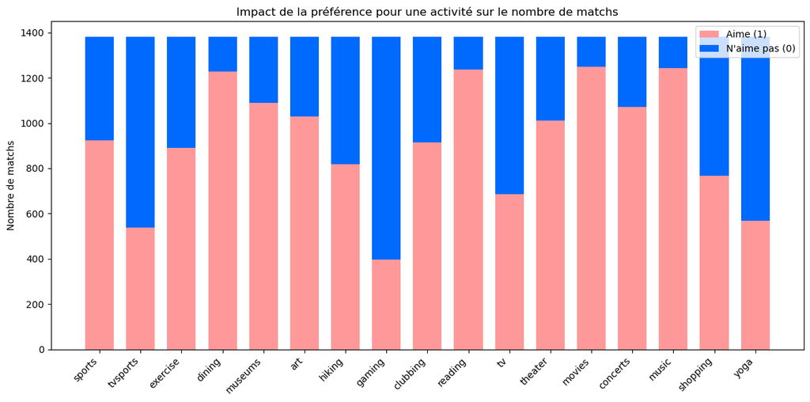

```python
#Création d'une figure de taille 12 x 6 pouces
fig, ax = plt.subplots(figsize=(12, 6))
#Taille du graphe
bar_width = 0.7
#mise en array de la colonne Activité avec comme paramètre "stop" qui correspond
# à la longeur de la colonne Activités
x = np.arange(len(results_df["Activité"]))

ax.bar(x, results_df["1"], width=bar_width, color="#ff9999", label="Aime (1)")
ax.bar(x, results_df["0"], bottom=results_df["1"], width=bar_width, color="#006aff", label="N'aime pas (0)")

ax.set_xticks(x)
ax.set_xticklabels(results_df["Activité"], rotation=45, ha="right")
ax.set_ylabel("Nombre de matchs")
ax.set_title("Impact de la préférence pour une activité sur le nombre de matchs")
ax.legend()

plt.tight_layout()
plt.show()
```

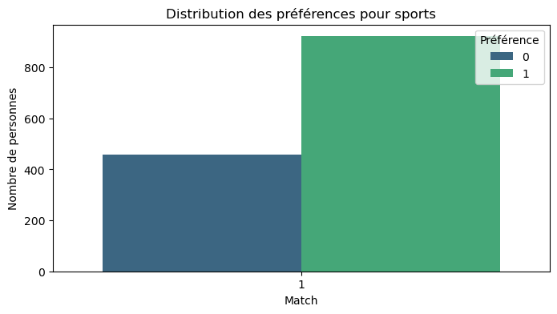

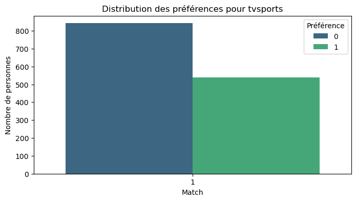

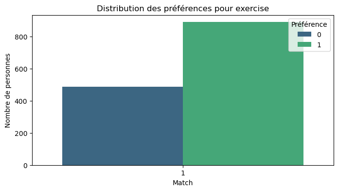

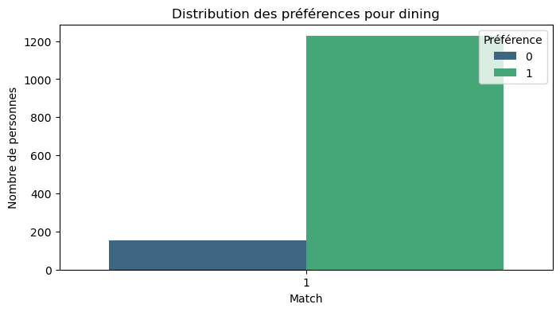

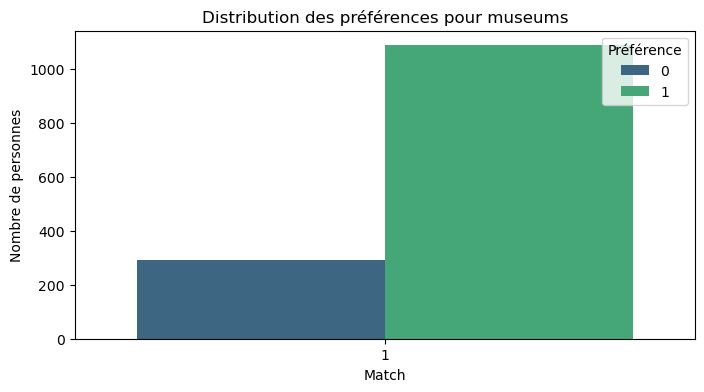

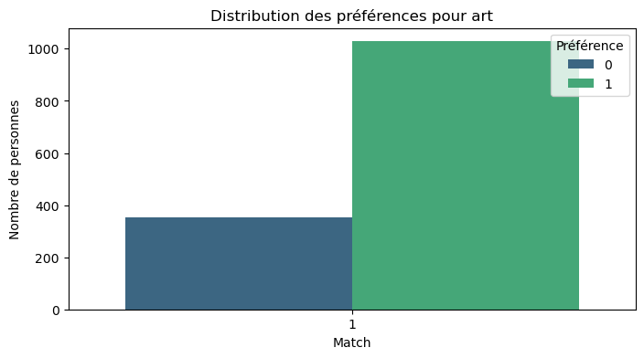

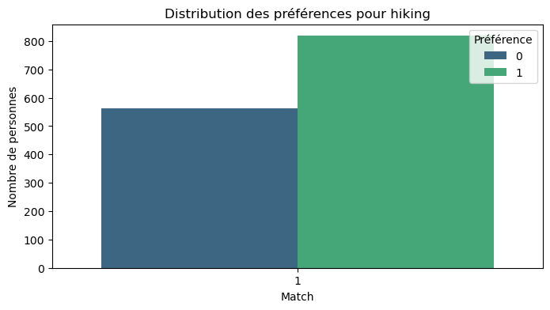

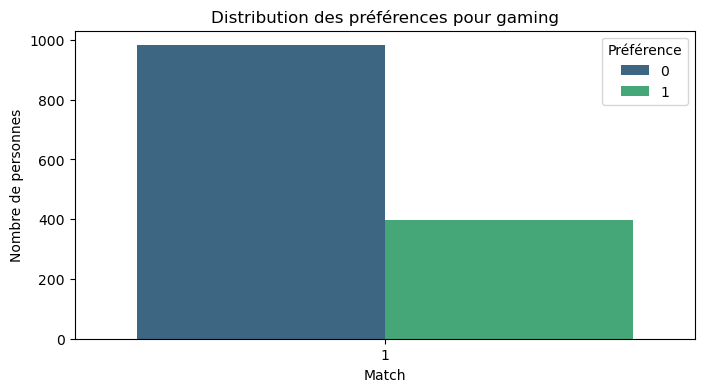

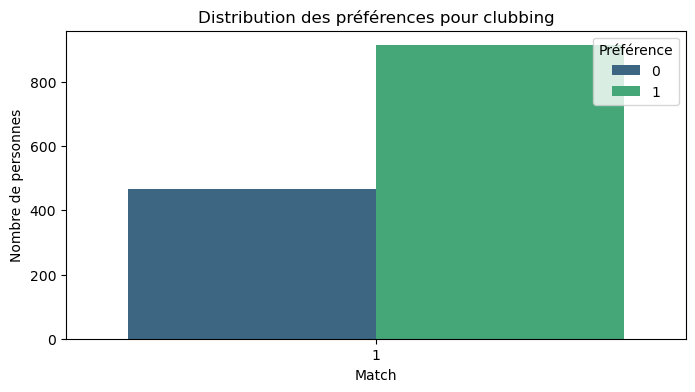

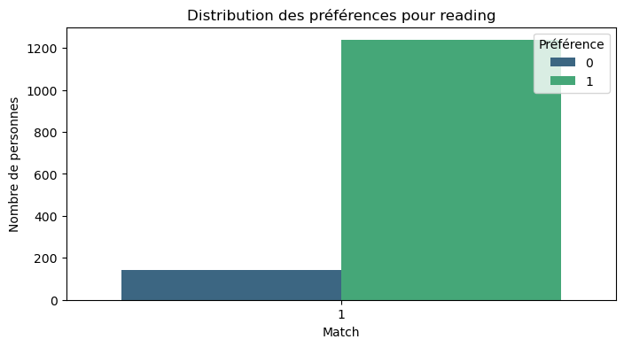

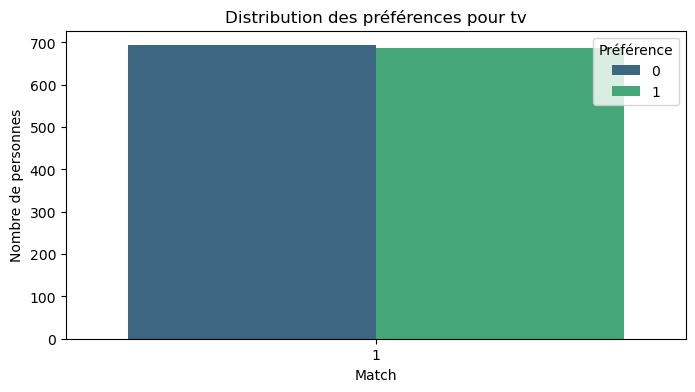

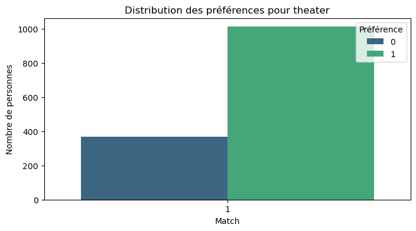

[6 more figures not shown]

```python
import matplotlib.pyplot as plt
for activity in df1activities:
    plt.figure(figsize=(8, 4))
    sns.countplot(data=df1activities, x='match', hue=df1activities[activity], palette='viridis')
    plt.title(f'Distribution des préférences pour {activity}')
    plt.xlabel('Match')
    plt.ylabel('Nombre de personnes')
    plt.legend(title='Préférence', loc='upper right')
    plt.show()
```

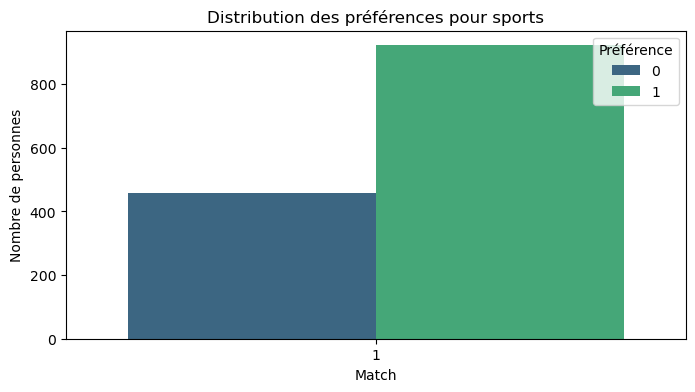

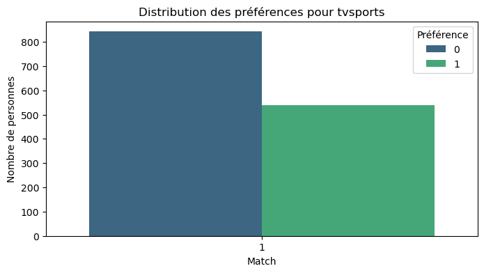

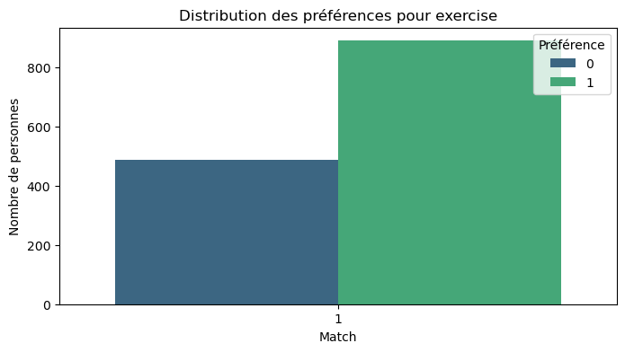

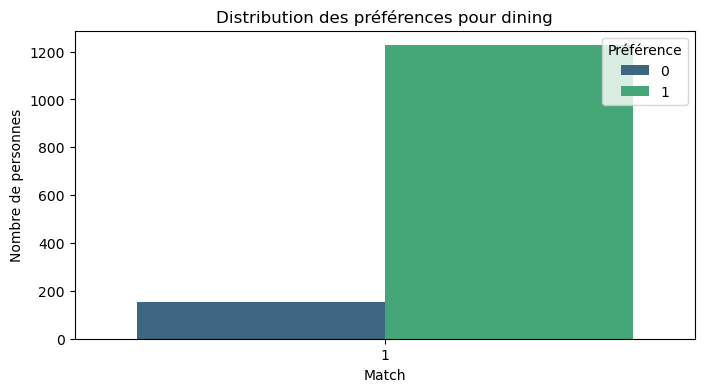

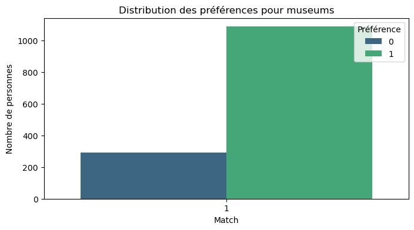

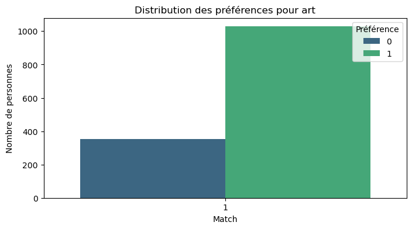

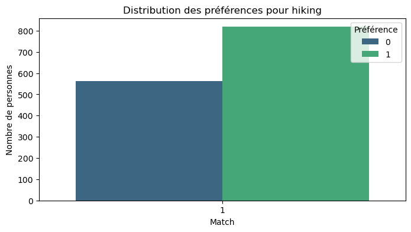

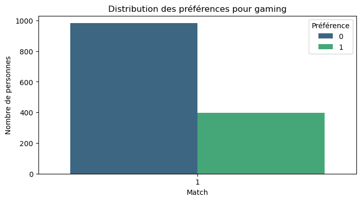

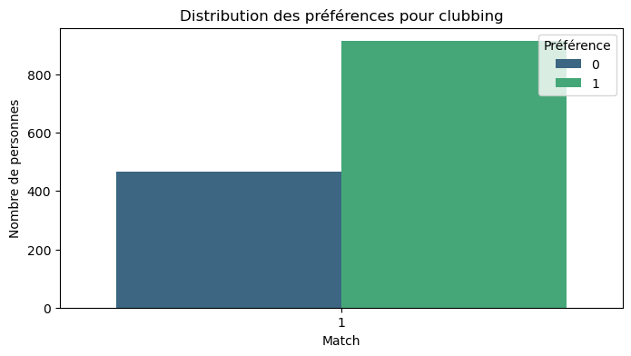

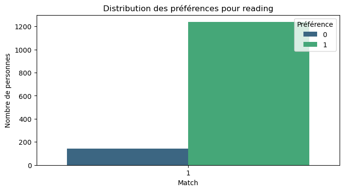

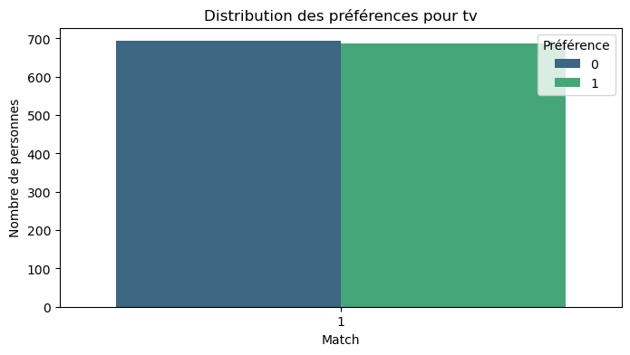

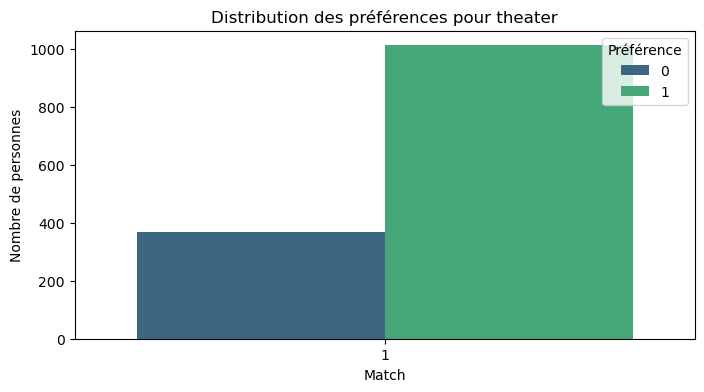

[6 more figures not shown]

```python
import matplotlib.pyplot as plt
for activity in df1activities:
    plt.figure(figsize=(8, 4))
    sns.countplot(data=df1activities, x='match', hue=df1activities[activity], palette='viridis')
    plt.title(f'Distribution des préférences pour {activity}')
    plt.xlabel('Match')
    plt.ylabel('Nombre de personnes')
    plt.legend(title='Préférence', loc='upper right')
    plt.show()
```